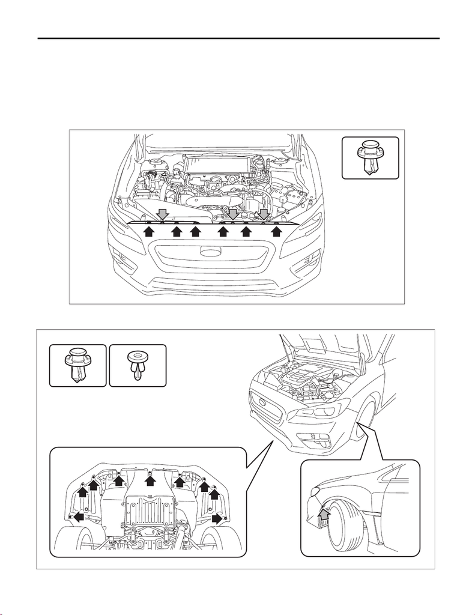

EI-30

Front Bumper

EXTERIOR/INTERIOR TRIM

8. Front Bumper

A: REMOVAL

1) Disconnect the ground cable from battery. <Ref. to NT-5, BATTERY, NOTE, Note.>

NOTE:

For models other than STI model, disconnect the ground terminal from battery sensor.

2) Remove the bumper face - front.

(1) Remove the clips and bolts, and remove the plate UPR - front.

(2) Remove the clips from the fender.

(3) Remove the clips at the lower side of the bumper face - front.

(4) Disconnect the integrated connector of the fog light assembly and turn signal light assembly.

EI-04340

EI-04313

[figure not shown]

EI-31

Front Bumper

EXTERIOR/INTERIOR TRIM

(5) Apply protective tape (A) to the light assembly - head.

(6) While pushing up the lower side (a) of the bumper face - front, release the engagement in the order

from (b) to (g).

CAUTION:

Do not pull forcibly. It may damage the flange section on the bumper face - front side when it comes

off from the claws of the bracket - front bumper.

NOTE:

Detach the opposite side in the same manner.

3) Remove the energy absorber foam.

4) Remove the bolts, and remove the bumper beam COMPL - front.

5) Remove the under cover - front. <Ref. to EI-21, REMOVAL, Front Under Cover.>

EI-04322

(a)

(b)

(c)

(g)

(e)

(d)

(A)

EI-04293

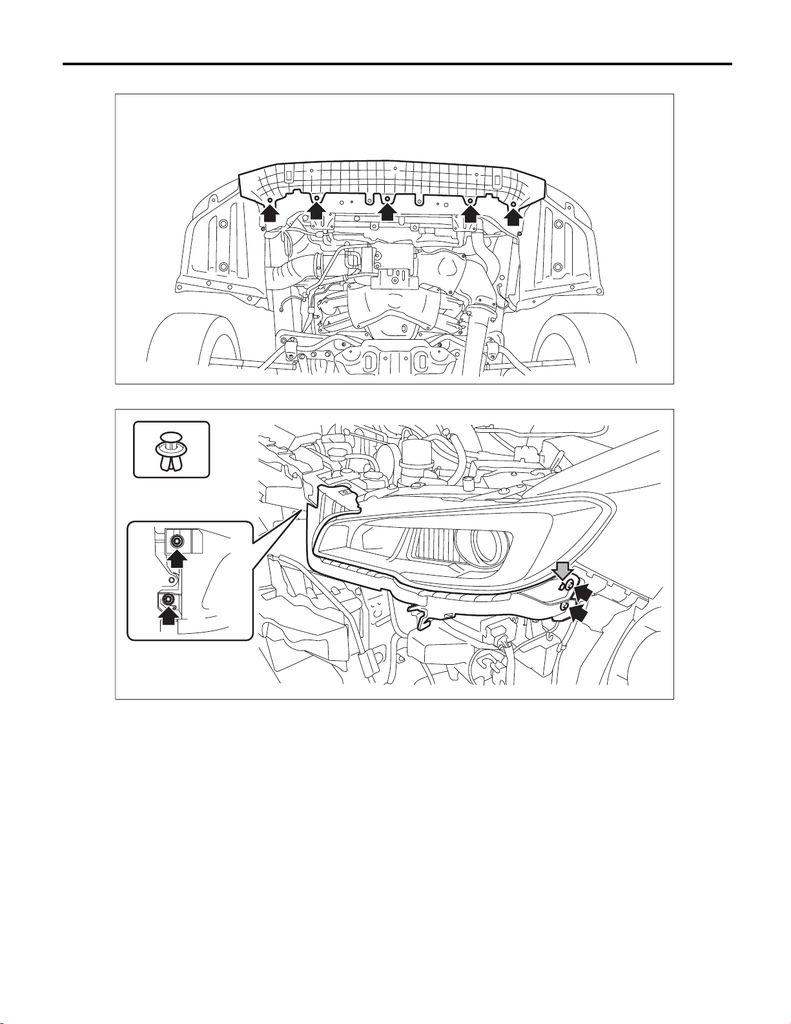

EI-32

Front Bumper

EXTERIOR/INTERIOR TRIM

6) Remove the bolts, and remove the bracket - front center LWR.

7) Remove the bolts and clips, and remove the bracket - front bumper corner.

EI-04405

LI-01722

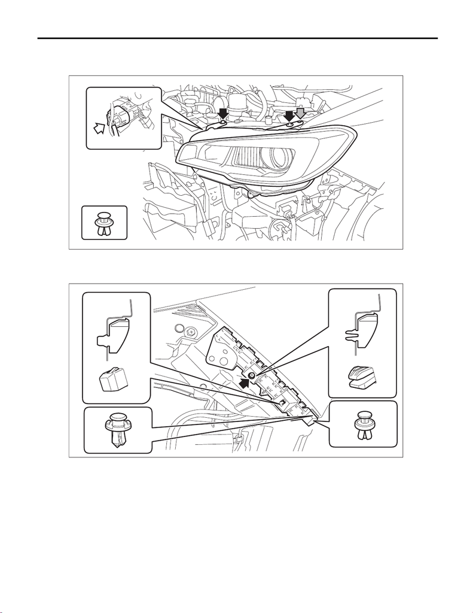

EI-33

Front Bumper

EXTERIOR/INTERIOR TRIM

8) Remove the light assembly - head.

(1) Disconnect the connector.

(2) Remove the bolts and clips, and remove the light assembly - head.

9) Remove the bracket - front bumper side.

(1) Remove the screws.

(2) Remove the claws from behind the fender COMPL - front, and remove the bracket - front bumper side.

10) Remove the fog light assembly - front. <Ref. to LI-41, REMOVAL, Front Fog Light Assembly.>

LI-01723

EI-04323

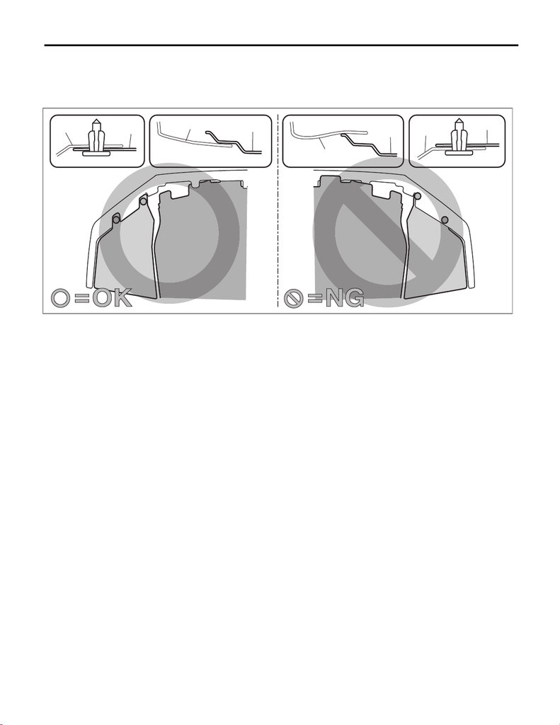

EI-34

Front Bumper

EXTERIOR/INTERIOR TRIM

B: INSTALLATION

CAUTION:

• Install so that the front end of the under cover (b) comes inside the bumper face - front (a), and the

front end of the mud guard (c) comes outside the bumper face - front (a).

• Before installing the bumper face, match the claws on the bracket - front bumper with the engaging

position of flange section on the bumper face side. If the engaging position is not correct, the flange

section may be broken or the clearance between fender panel and bumper face may not be uniform.

1) Install the fog light assembly - front.

2) Install the bracket - front bumper side.

Tightening torque:

7.5 N·m (0.8 kgf-m, 5.5 ft-lb)

3) Install the light assembly - head.

Tightening torque:

7.5 N·m (0.8 kgf-m, 5.5 ft-lb)

4) Install the bracket - front bumper corner.

Tightening torque:

7.5 N·m (0.8 kgf-m, 5.5 ft-lb)

5) Install the bracket - front center LWR.

Tightening torque:

7.5 N·m (0.8 kgf-m, 5.5 ft-lb)

7) Install the bumper beam COMPL - front.

Tightening torque:

32 N·m (3.3 kgf-m, 23.6 ft-lb)

8) Install the energy absorber foam.

9) Install the bumper face - front.

NOTE:

Secure the flange section of the bumper face - front to the bracket - front bumper side.

Tightening torque:

Plate UPR - front: 7.5 N·m (0.8 kgf-m, 5.5 ft-lb)

10) Connect the battery ground terminal. <Ref. to NT-5, BATTERY, NOTE, Note.>

NOTE:

For models other than STI model, connect the ground terminal to battery sensor.

COM00138

(a)

(c)

(b)

(a)

(a)

(c)

(b)

(a)

[figure not shown]

EI-35

Front Bumper

EXTERIOR/INTERIOR TRIM

11) Adjust the headlight beam and fog light beam.

• Adjust the headlight beam. <Ref. to LI-26, HEADLIGHT BEAM ADJUSTMENT, ADJUSTMENT, Headlight

Assembly.>

• Adjust the fog light beam. (Model with fog light) <Ref. to LI-43, FOG LIGHT AIMING, ADJUSTMENT, Front

Fog Light Assembly.>

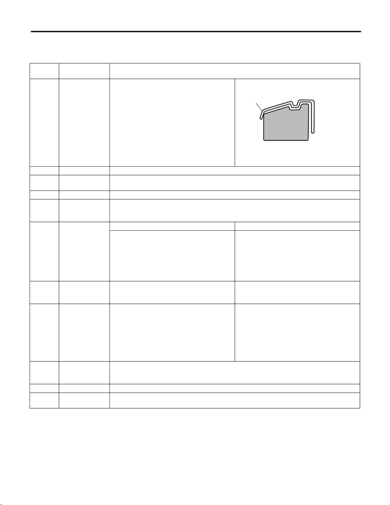

EI-36

Front Bumper

EXTERIOR/INTERIOR TRIM

C: REPAIR

1. COATING METHOD FOR PP BUMPER

Process

No.

Process name Job contents

1

Bumper installa-

tion

Place the bumper on a paint worktable as

required. Use the paint worktable conforming to

inner shape of bumper if possible.

(1) Bumper

(2) Set bumper section

2 Masking Mask the black base with masking tape. Use masking tape for PP.

3

Degreasing/

cleaning

Clean all parts to be painted with appropriate cleaning solvent, normal alcohol, etc. to remove dirt,

oil, grease, etc.

4 Primer paint Apply primer to all parts to be painted, using spray gun. Use primer (clear).

5Drying

Dry at normal temperature. [10 — 15 min. at 20°C (68°F)]

In half-dried condition, PP primer paint is dissolved by solvent, e.g. thinner, etc.

Therefore, if dust or dirt must be removed, use ordinary alcohol etc.

6 Top coat paint (I)

Non-colored Metallic paint

Use section (block) paint for top coat.

For paint/hardener mixture, observe the specifi-

cations recommended by the manufacturers.

• Viscosity: 10 — 13 sec./20°C (68°F)

• Film thickness: 35 — 45 µ

• Spraying pressure: 245 — 343 kPa

(2.5 — 3.5 kgf/cm

2

, 36 — 50 psi)

Use section (block) paint for top coat.

For paint/hardener mixture, observe the specifi-

cations recommended by the manufacturers.

• Viscosity: 10 — 13 sec./20°C (68°F)

• Film thickness: 15 — 20 µ

• Spraying pressure: 245 — 343 kPa

(2.5 — 3.5 kgf/cm

2

, 36 — 50 psi)

7 Drying Not required.

Dry at normal temperature [at least 10 min. at

20°C (68°F)].

In half-dried condition, avoid dust, dirt.

8 Top coat paint (II) Not required.

Apply a clear coat to parts with top coat paint

(I), three times at 5 — 7 minute intervals.

For paint/hardener mixture, observe the specifi-

cations recommended by the manufacturers.

• Viscosity: 14 — 16 sec./20°C (68°F)

• Film thickness: 25 — 30 µ

• Spraying pressure: 245 — 343 kPa

(2.5 — 3.5 kgf/cm

2

, 36 — 50 psi)

9Drying

60°C (140°F), 60 min. or 80°C (176°F), 30 min.

If the temperature is higher than 80°C (176°F), PP may be deformed. Keep maximum tempera-

ture at 80°C (176°F) or less.

10 Inspection Check paint.

11

Removal of mask-

ing

Remove the masking tape applied in procedure 2.

EI-00234

(2)

(1)

[figure not shown]

EI-37

Front Bumper

EXTERIOR/INTERIOR TRIM

2. REPAIR INSTRUCTIONS FOR COLORED PP BUMPER

NOTE:

If grained PP bumper surface is damaged, it cannot normally be restored to its former condition. Damages

limited to the shallow scratches that cause only a change in the luster of the base material or coating, can be

almost fully restored. Before repairing a damaged area, explain this point to the customer and obtain an un-

derstanding about the matter.

Repair methods are outlined below, based on a classification of the extent of damage.

1) Minor damage causing only a change in the luster of the bumper due to a light touch

Almost restorable.

2) Deep damage caused by scratching with fences etc.

A dent cannot be repaired but a whitened or swelled part can be removed.

Process

No.

Process name Job contents

1 Cleaning Clean the area to be repaired using water.

2 Sanding Grind the repairing area with #500 sand paper in a “feathering” motion.

3 Finish

Resin section Coated section

Repeatedly apply wax to the affected area

using soft cloth (such as flannel).

Recommended wax: Tire wax or equivalent

Perform either the same procedures as for the

resin section or process No. 18 and subse-

quent in section 3), depending on the degree

and nature of damage.

Polish the waxed area with clean cloth after 5 —

10 minutes.

Process

No.

Process name Job contents

1 Cleaning Clean the damaged area with water.

2

Removal of dam-

aged area

Cut off protruding area, if any, due to collision, using a putty knife.

3 Sanding Grind the affected area with #100 — #500 sand paper.

4 Finish

Resin section Coated section

Same as process No. 3 in section “1)”.

Perform process No. 12 and subsequent opera-

tions in section “3)”.

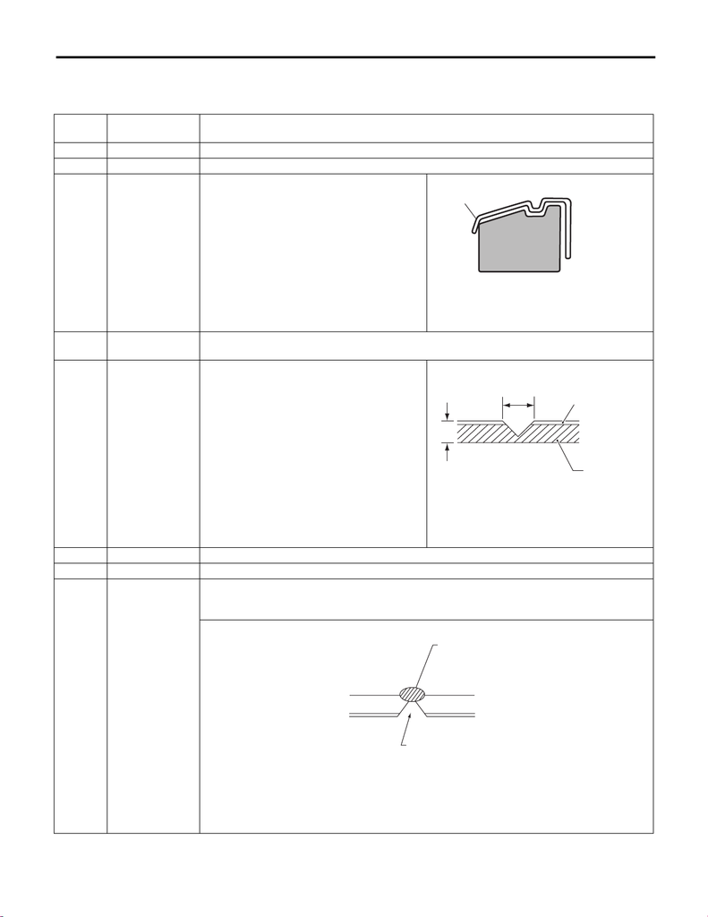

EI-38

Front Bumper

EXTERIOR/INTERIOR TRIM

3) Deep damage such as a break or hole that requires filling

Much of the peripheral grained surface must be sacrificed for repair. The degree of restoration is not really

worth the expense. (The surface, however, will become almost flush with adjacent areas.)

Process

No.

Process name Job contents

1 Bumper removal Remove the bumper as required.

2 Removal of parts Remove the parts built into bumper as required.

3

Bumper place-

ment

Place the bumper on a paint worktable as

required.

It is recommended to use the paint worktable

conforming to internal shape of bumper.

(1) Bumper

(2) Set bumper section

4

Surface prepara-

tion

Remove dust, oil, etc. from areas to be repaired and surrounding areas, using an appropriate sol-

vent (appropriate cleaning solvent or alcohol, etc.).

5 Cutting

If the damage is a crack or a hole, cut a guide

slit of 20 to 30 mm (0.79 to 1.18 in) in length

along the crack or hole up to the bumper base

surface. Next, use a knife or grinder to carve a

V-shaped groove in the area for repair.

(1) Paint surface

(2) PP base surface

(3) 20 — 30 mm (0.79 — 1.18 in)

(4) 3 mm (0.12 in)

6 Sanding (I) Grind beveled surface with sand paper (#40 — #60) to smooth finish.

7 Cleaning Clean the sanded surface with the same solvent as used in process No. 4.

8

Temporary weld-

ing

Grind the side just opposite the beveled area with sand paper (#40 — #60) and clean using a sol-

vent.

Temporarily spot-weld the side, using PP welding rod and heater gun.

(1) Welded point (Use heater gun and PP welding rod)

(2) PP base surface

(3) Beveled section

NOTE:

• Do not melt welding rod until it flows out. This results in reduced strength.

• Leave the welded spot unattended until it cools completely.

EI-00234

(2)

(1)

EI-00235

(4)

(2)

(1)

(3)

EI-00236

(1)

(2)

(3)

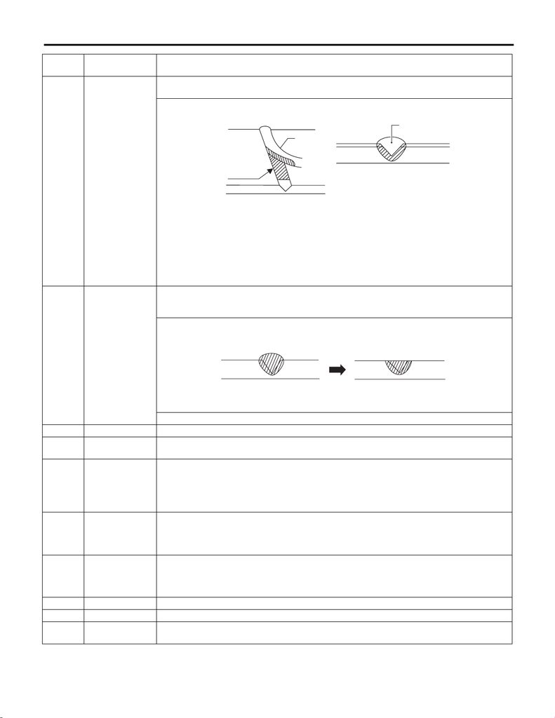

EI-39

Front Bumper

EXTERIOR/INTERIOR TRIM

9 Welding

Using a heater gun and PP welding rod, weld the beveled spot while melting both the rod and

damaged area.

(1) Welding rod

(2) Melt hatched area

(3) Section

NOTE:

• Melt the sections indicated by hatched area.

• Do not melt the welding rod until it flows out, in order to provide strength.

• Always keep the heater gun 1 to 2 cm (0.4 to 0.8 in) away from the welding spot.

• Leave the welded spot unattended until it cools completely.

10 Sanding (II)

Remove excess part of weld with a putty knife. If a drill or disc wheel is used instead of the knife,

operate it at a rate less than 1,500 rpm and grind the excess part little by little. A higher rpm will

cause the PP substrate to melt from the heat.

Sand the welded spot smooth with #240 sand paper.

11 Masking Mask the black substrate section using masking tape.

12

Cleaning/

degreasing

Completely clean the entire coated area, using solvent similar to that used in process No. 4.

13 Primer coating

Apply a coat of primer for bumpers to the repaired surface and its surrounding areas. Mask these

areas, if necessary.

NOTE:

Be sure to apply a coat of primer using a spray gun at a pressure of 245 — 343 kPa (2.5 — 3.5

kgf/cm

2

, 36 — 50 psi).

14 Leave unattended

Leave the repaired area unattended at 20°C (68°F) for 10 to 15 minutes until primer is half-dry.

NOTE:

If dirt or dust comes in contact with the coated area, wipe it off with a cloth dampened with alcohol.

(Do not use thinner since the coated area tends to melt.)

15 Surfacer coating

Apply a coat of surfacer for PP bumpers to the repaired area two or three times at an interval of 3

— 5 minutes.

For surfacer/hardener mixture, viscosity and paint thickness, observe the specifications of the sur-

facers to be used.

16 Drying Allow the coated surface to dry for 20 minutes at 20°C (68°F) [or 30 minutes at 60°C (140°F)].

17 Sanding (III) Sand the coated surface and its surrounding areas using #400 sand paper and water.

18

Cleaning/

degreasing

Same as process No. 12.

Process

No.

Process name Job contents

(1)

(2)

(2)

(3)

EI-00237

EI-00042

[figure not shown]

EI-40

Front Bumper

EXTERIOR/INTERIOR TRIM

19 Top coat (I)

Non-colored Metallic paint

Use a “block” coating method.

For paint/hardener mixture, observe the specifi-

cations recommended by the manufacturers.

• Viscosity: 11 — 13 sec./20°C (68°F)

• Coating film thickness: 40 — 50 µ

• Spraying pressure: 245 — 343 kPa

(2.5 — 3.5 kgf/cm

2

, 36 — 50 psi)

Use a “block” coating method.

For paint/hardener mixture, observe the specifi-

cations recommended by the manufacturers.

• Viscosity: 11 — 13 sec./20°C (68°F)

• Coating film thickness: 20 — 30 µ

• Spraying pressure: 245 — 343 kPa

(2.5 — 3.5 kgf/cm

2

, 36 — 50 psi)

20 Leave unattended Not required.

Leave unattended at 20°C (68°F) for at least 10

minutes until the topcoated area is half-dry.

NOTE:

Be careful to keep dust or dirt from coming in

contact with the affected area.

21 Top coat (II) Not required.

Apply a clear coat three times at an interval of 3

to 5 minutes.

For paint/hardener mixture, observe the specifi-

cations recommended by the manufacturers.

• Viscosity: 10 — 13 sec./20°C (68°F)

• Coating film thickness: 20 — 30 µ

• Spraying pressure: 245 — 343 kPa

(2.5 — 3.5 kgf/cm

2

, 36 — 50 psi)

22 Drying

Allow the coated surface to dry for two hours at 20°C (68°F) or 30 minutes at 60°C (140°F).

NOTE:

Do not allow the temperature to exceed 80°C (176°F) since this will deform the PP substrate.

23 Inspection Carefully check the condition of the repaired area.

24

Removal of mask-

ing

Remove the masking tape applied in process No. 11 and 13.

25 Parts installation Install parts on the bumper in reverse order of removal.

26

Bumper installa-

tion

Install the bumper.

Process

No.

Process name Job contents